# LEO Stats

Barry von Tobel

1/18/2021

# Intro -

Data dated 07Jan21

This analysis downloads from space-track the latest gp and cdm file sets using manually changed file date, which for this document is 07Jan21. This document is produced using the RMarkdown syntax that comes bundled with RStudio, an open-source R Integrated Development Environment. The R code for the analysis is embedded in the document, but the ‘ECHO’ is set to false so the code and code comments are not displayed on the page. A nice feature of RMarkdown and most other types of Web document tools is that the pagination isn’t enforced, so the document becomes one continuous page, a nice feature when the document has images, graphs, and tables. An future enhanced document can have the index of the heading on the left, which aids in navigation.

# LEO Statistics

This graph depicts all the cataloged items in the space-track download. It is factored into the 4 categories used by space.track, Payload, Debris, Rocket Body, and TBA.

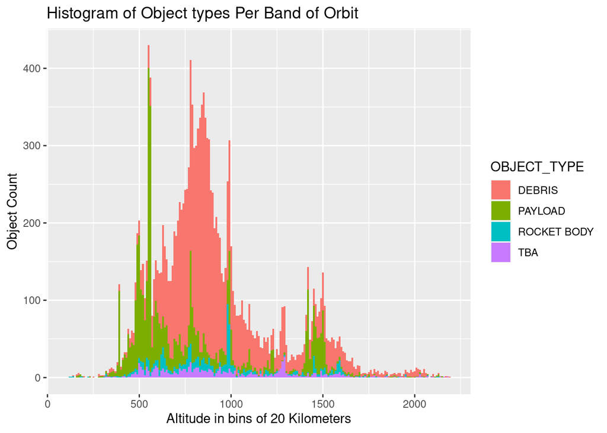

# Count Density

This second graph depicts all the cataloged items in the space-track same as the above histogram with showing normalized density as a line and the y axis. Normalized density in this context refers to the area under the density curve equal 1.

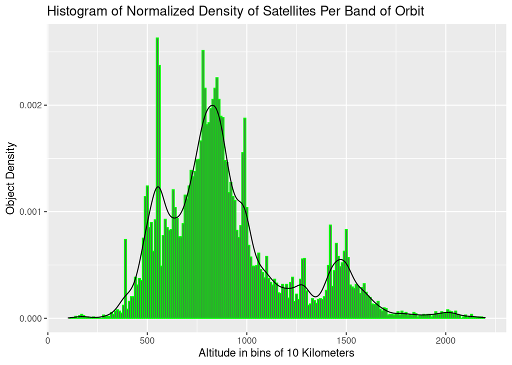

This is a table of all the LEO assets that are depicted in the histograms.

|  | OBJECT_ID | OBJECT_NAME | NORAD_CAT_ID | OBJECT_TYPE | altitude | bins |
| --- | --- | --- | --- | --- | --- | --- |
| 2 | 1959-001A | VANGUARD 2 | 11 | PAYLOAD | 1752.38513007019 | (1750,1760] |
| 3 | 1959-001B | VANGUARD R/B | 12 | ROCKET BODY | 1946.86623498882 | (1940,1950] |
| 5 | 1959-007A | VANGUARD 3 | 20 | PAYLOAD | 1892.04979966411 | (1890,1900] |
| 6 | 1959-009A | EXPLORER 7 | 22 | PAYLOAD | 588.19789128701 | (580,590] |
| 7 | 1960-002B | TIROS 1 | 29 | PAYLOAD | 654.060829827591 | (650,660] |
| 8 | 1960-007A | TRANSIT 2A | 45 | PAYLOAD | 786.378462080969 | (780,790] |
| 9 | 1960-007B | SOLRAD 1 (GREB) | 46 | PAYLOAD | 734.74149204811 | (730,740] |
| 10 | 1960-007C | THOR ABLESTAR R/B | 47 | ROCKET BODY | 758.478335508993 | (750,760] |
| 11 | 1960-009B | DELTA 1 R/B | 50 | ROCKET BODY | 1599.01888020825 | (1590,1600] |
| 12 | 1960-009C | ECHO 1 DEB (METAL OBJ) | 51 | DEBRIS | 1607.05273427375 | (1600,1610] |

[output cut: 16341 more lines]

## Volume Density

Graph that portrays the density of objects per bin’s Hollow Sphere area. The caculation is the number of objects within a band, divided by the volume in cubic kilometers of the hollow sphere which will give objects per cubic kilometer.

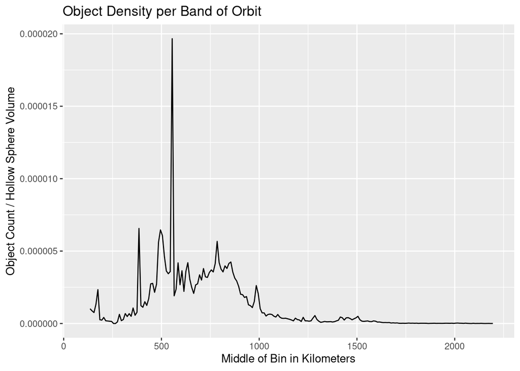

# Probability

This section merges the CDM file into the LEO catalog file. The CDM file, downloaded from space-track often has several entries for the same objects, often a message for object A proximity to Object B, and conversely Object B’s proximity to Object A. These same objects are aggregated with each other and the PC (Probability) is averaged over the number of similar CDMs to what is called the ‘Mean PC’ The end result is that each bin in the histogram has a calculated Mean PC. A density line is calculated which will be used to perform a covariance analysis.

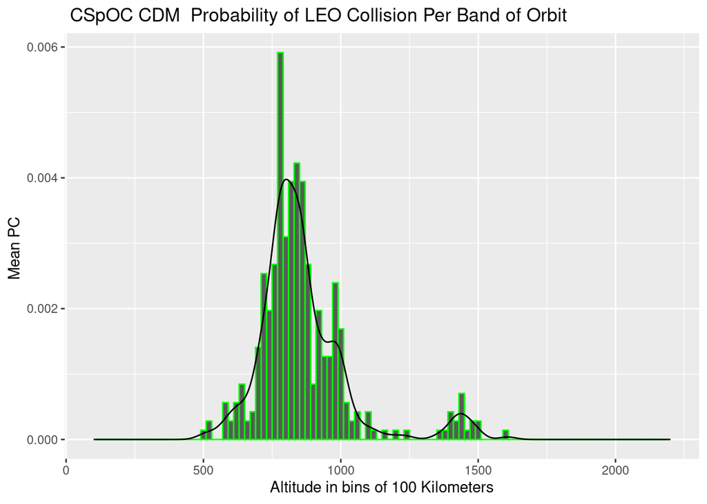